# Figure S6

John Favate

2021-01-08 17:01:31

```r
# Prevent printing of warnings and such in the HTML
knitr::opts_chunk$set(warning = FALSE, message = FALSE, fig.align = "center")
```

```r
library(tidyverse)
library(patchwork)
library(ggpubr)
library(ggridges)

all.data <- read_csv("../../data_frames/all_data.csv")
```

Set line order and colors for axis.

```r
mut.levels <- all.data %>%
  select(line, mutator) %>%
  arrange(mutator, line) %>%
  unique() %>%
  pull(line)

all.data$line <- factor(all.data$line, levels = mut.levels)

mut.colors <- c(rep("black", 6), rep("firebrick3", 5))
```

### Panel A

Find the top 100 up and downregulated genes in RNA-seq and use that as the order for the x axis

```r
hmdf <- all.data %>%
  filter(gene_type == "ECB") %>%
  select(line, target_id, starts_with("ds_log2foldchange")) %>%
  pivot_longer(starts_with("ds_log2foldchange"), names_to = "seqtype", values_to = "l2fc")

ordered.genes <- hmdf %>%
  filter(seqtype == "ds_log2foldchange_rna") %>%
  group_by(target_id) %>%
  summarise(mean_fc = mean(l2fc, na.rm = TRUE)) %>%
  ungroup() %>%
  filter(!is.nan(mean_fc)) %>%
  arrange(mean_fc) %>%
  pull(target_id)

top.100 <- c(head(ordered.genes, n = 100), tail(ordered.genes, n = 100))
```

Factor the target_id column with the order, factor the line column, and set a max l2fc threshold to display

```r
hmdf$target_id <- factor(hmdf$target_id, levels = ordered.genes)

hmdf$line <- factor(hmdf$line, levels = mut.levels)

# pick a max fold change to display
threshold <- 3

# change fold changes larger than that to the threshold
hmdf$l2fc[hmdf$l2fc > threshold] <- threshold

hmdf$l2fc[hmdf$l2fc < -threshold] <- -threshold
```

Facet labels for the graph

```r
scale.labels <- c(paste("\u2264", paste0("-", threshold), sep = ""),
                  "",
                  0,
                  "",
                  paste("\u2265", threshold, sep = ""))

fac.labs <- c("ds_log2foldchange_rna" = "RNA-seq",
              "ds_log2foldchange_ribo" = "Ribo-seq",
              "Top 100 upregulated" = "Ribo-seq Top 100 upregulated",
              "Top 100 downregulated" = "Ribo-seq Top 100 downregulated")
```

The graph

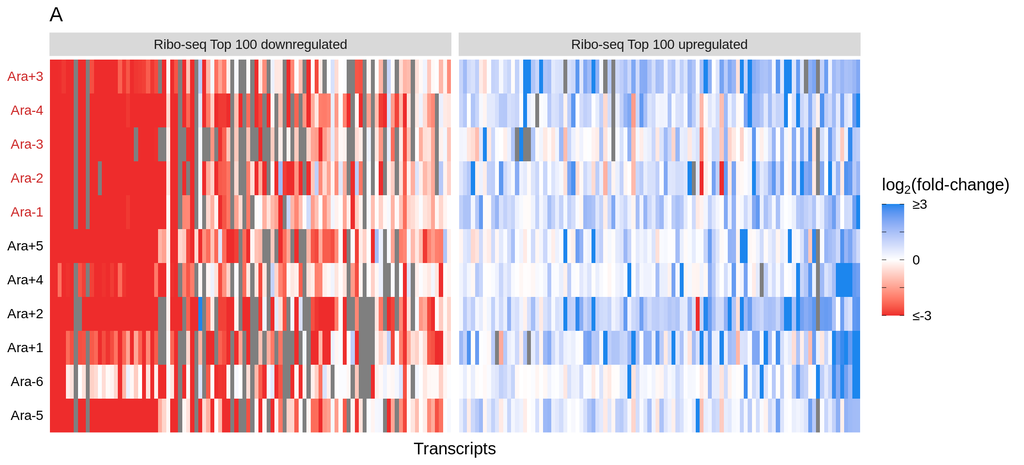

```r
pa <- hmdf %>%
  filter(target_id %in% top.100 & seqtype == "ds_log2foldchange_ribo") %>%
  mutate(gene.spec = ifelse(target_id %in% head(ordered.genes, n = 100), "Top 100 downregulated", "Top 100 upregulated")) %>%
  ggplot(., aes(target_id, line, fill = l2fc))+
  geom_raster()+
  scale_fill_gradientn(colours = c("firebrick2", "white", "dodgerblue2"),
                       name = expression(paste(log[2], "(fold-change)", sep = "")),
                       labels = scale.labels,
                       breaks = c(-threshold, (-threshold/2), 0, (threshold/2), threshold),
                       guide = guide_colorbar(ticks.colour = "black"))+
  theme(panel.background = element_blank(),
        axis.text.x = element_blank(),
        axis.ticks = element_blank(),
        panel.grid = element_blank(),
        axis.text.y = element_text(color = mut.colors),
        text = element_text(size = 13),
        legend.position = "right",
        legend.direction = "vertical")+
  labs(x = "Transcripts",
       y = NULL,
       title = "A")+
  facet_wrap(~gene.spec, scales = "free_x", labeller = as_labeller(fac.labs))

pa
```

### Panel B

Ridges for significant fold changes in each line

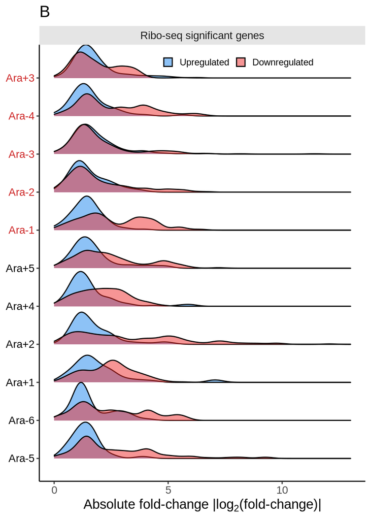

```r
bdf.rna <- all.data %>%
  filter(ds_padj_rna <= .01 & deleted == FALSE)

bdf.ribo <- all.data %>%
  filter(ds_padj_ribo <= .01 & deleted == FALSE)

bdf <- bind_rows(bdf.rna, bdf.ribo) %>%
  select(line, target_id, starts_with("ds_log2")) %>%
  pivot_longer(where(is.numeric)) %>%
  mutate(direc = ifelse(value < 0, "down", "up"))

bdf$line <- factor(bdf$line, levels = mut.levels)

bdf$name <- factor(bdf$name, levels = c("ds_log2foldchange_rna", "ds_log2foldchange_ribo"))

c.fac.labs <- c("ds_log2foldchange_rna" = "RNA-seq significant genes",
                "ds_log2foldchange_ribo" = "Ribo-seq significant genes")

bdf$direc <- factor(bdf$direc, levels = c("up", "down"))

pb <- bdf %>%
  filter(name == "ds_log2foldchange_ribo") %>%
  ggplot(., aes(abs(value), line, fill = direc))+
  geom_density_ridges(alpha = .5, scale = .999)+
  scale_fill_manual(values = c("dodgerblue2", "firebrick2"), labels = c("Upregulated", "Downregulated"), name = NULL)+
  theme_classic()+
  theme(text = element_text(size = 13),
        axis.text.y = element_text(color = mut.colors),
        strip.background = element_rect(fill = "grey90", color = NA),
        legend.position = c(.6, .96),
        legend.direction = "horizontal",
        legend.key.size = unit(3.4, "mm"),
        legend.text = element_text(size = 9),
        legend.background = element_blank())+
  labs(x = expression(paste("Absolute fold-change ", "|", log[2], "(fold-change)", "|", sep = "")),
       y = NULL,
       title = "B")+
  facet_wrap(~name, labeller = as_labeller(c.fac.labs))+
  scale_x_continuous(limits = c(0, 13))

pb
```

### Panel C

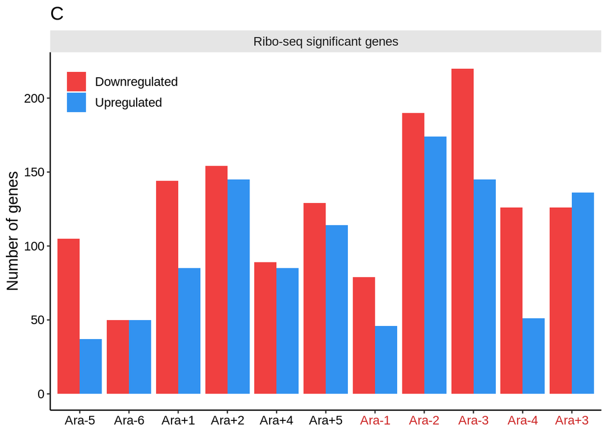

```r
pc <- all.data %>%
  filter(ds_padj_ribo <= .01) %>%
  mutate(direc = ifelse(ds_log2foldchange_ribo < 0, "down", "up"),
         fac = "Ribo-seq significant genes") %>%
  group_by(line, direc, mutator, fac) %>%
  tally() %>%
  ungroup() %>%
  ggplot(., aes(line, n, fill = direc))+
  geom_col(position = position_dodge(), alpha = .9)+
  scale_fill_manual(values = c("firebrick2", "dodgerblue2"), labels = c("Downregulated", "Upregulated"), name = NULL)+
  theme_classic()+
  theme(text = element_text(size = 13),
        axis.text.y = element_text(color = mut.colors),
        strip.background = element_rect(fill = "grey90", color = NA),
        legend.background = element_blank(),
        axis.text.x = element_text(color = mut.colors),
        legend.position = c(.13, .9))+
  facet_wrap(~fac)+
  labs(x = NULL,
       y = "Number of genes",
       title = "C")

pc
```

### Panel D

This yields a list of two matrices of line to line correlations, one per seqtype.

```r
cor.list <- all.data %>%
  filter(gene_type == "ECB") %>%
  select(line, target_id, ds_log2foldchange_rna, ds_log2foldchange_ribo) %>%
  pivot_longer(., cols = starts_with("ds_log"), names_to = "seqtype", values_to = "l2fc") %>%
  split(.$seqtype) %>%
  map(function(x){
    x %>%
      pivot_wider(., -seqtype, names_from = line, values_from = l2fc) %>%
      column_to_rownames("target_id") %>%
      cor(method = "spearman", use = "pairwise.complete.obs")
  })

cor.list.sig <- all.data %>%
  filter(gene_type == "ECB" & (ds_padj_rna <= .01 | ds_padj_ribo <= .01)) %>%
  select(line, target_id, ds_log2foldchange_rna, ds_log2foldchange_ribo) %>%
  pivot_longer(., cols = starts_with("ds_log"), names_to = "seqtype", values_to = "l2fc") %>%
  split(.$seqtype) %>%
  map(function(x){
    x %>%
      pivot_wider(., -seqtype, names_from = line, values_from = l2fc) %>%
      column_to_rownames("target_id") %>%
      cor(method = "spearman", use = "pairwise.complete.obs")
  })

cor.list
```

```
## $ds_log2foldchange_ribo
##           Ara-1     Ara-2      Ara-3     Ara-4     Ara-5     Ara-6      Ara+1
## Ara-1 1.0000000 0.3818406 0.22377702 0.5153975 0.3899535 0.4184914 0.50044094
## Ara-2 0.3818406 1.0000000 0.32357210 0.5590838 0.1921515 0.3816636 0.20734190
## Ara-3 0.2237770 0.3235721 1.00000000 0.2901377 0.1757407 0.3187054 0.09296733
## Ara-4 0.5153975 0.5590838 0.29013768 1.0000000 0.3643144 0.4043228 0.34912236
## Ara-5 0.3899535 0.1921515 0.17574067 0.3643144 1.0000000 0.2245332 0.56482915
## Ara-6 0.4184914 0.3816636 0.31870539 0.4043228 0.2245332 1.0000000 0.22694398
## Ara+1 0.5004409 0.2073419 0.09296733 0.3491224 0.5648292 0.2269440 1.00000000
## Ara+2 0.3709222 0.3173482 0.27748103 0.5157572 0.4053403 0.2890156 0.44387894
## Ara+3 0.4171874 0.2527806 0.23446229 0.5374875 0.4837099 0.1887731 0.48524867
## Ara+4 0.3679902 0.3107595 0.12122495 0.4194048 0.3379478 0.4789365 0.33120260
## Ara+5 0.2501029 0.1472405 0.26273548 0.1951936 0.3433548 0.3141209 0.34778742
##           Ara+2     Ara+3     Ara+4     Ara+5
## Ara-1 0.3709222 0.4171874 0.3679902 0.2501029
## Ara-2 0.3173482 0.2527806 0.3107595 0.1472405
## Ara-3 0.2774810 0.2344623 0.1212249 0.2627355
## Ara-4 0.5157572 0.5374875 0.4194048 0.1951936
## Ara-5 0.4053403 0.4837099 0.3379478 0.3433548
## Ara-6 0.2890156 0.1887731 0.4789365 0.3141209
## Ara+1 0.4438789 0.4852487 0.3312026 0.3477874
## Ara+2 1.0000000 0.6404046 0.3114327 0.4956112
## Ara+3 0.6404046 1.0000000 0.2749158 0.2862106
## Ara+4 0.3114327 0.2749158 1.0000000 0.3533387
## Ara+5 0.4956112 0.2862106 0.3533387 1.0000000
##
## $ds_log2foldchange_rna
##           Ara-1     Ara-2     Ara-3     Ara-4     Ara-5     Ara-6     Ara+1
## Ara-1 1.0000000 0.4381953 0.1892171 0.5429213 0.4222690 0.4694143 0.5573666
## Ara-2 0.4381953 1.0000000 0.3065989 0.5903141 0.2130172 0.3896053 0.2588203
## Ara-3 0.1892171 0.3065989 1.0000000 0.2563318 0.1687104 0.2086759 0.1424599
## Ara-4 0.5429213 0.5903141 0.2563318 1.0000000 0.3528187 0.4426128 0.3998542
## Ara-5 0.4222690 0.2130172 0.1687104 0.3528187 1.0000000 0.2551678 0.6084553
## Ara-6 0.4694143 0.3896053 0.2086759 0.4426128 0.2551678 1.0000000 0.3301429
## Ara+1 0.5573666 0.2588203 0.1424599 0.3998542 0.6084553 0.3301429 1.0000000
## Ara+2 0.3992633 0.3070836 0.3050082 0.5074437 0.4564213 0.3068967 0.4795266
## Ara+3 0.4405763 0.2915236 0.2731473 0.5016245 0.4990768 0.2707567 0.5249977
## Ara+4 0.4056809 0.3323700 0.1566999 0.4413777 0.3308248 0.5040541 0.3466187
## Ara+5 0.2514967 0.1282031 0.2891581 0.1999265 0.3321900 0.3139637 0.3317464
##           Ara+2     Ara+3     Ara+4     Ara+5
## Ara-1 0.3992633 0.4405763 0.4056809 0.2514967
## Ara-2 0.3070836 0.2915236 0.3323700 0.1282031
## Ara-3 0.3050082 0.2731473 0.1566999 0.2891581
## Ara-4 0.5074437 0.5016245 0.4413777 0.1999265
## Ara-5 0.4564213 0.4990768 0.3308248 0.3321900
## Ara-6 0.3068967 0.2707567 0.5040541 0.3139637
## Ara+1 0.4795266 0.5249977 0.3466187 0.3317464
## Ara+2 1.0000000 0.6405791 0.3301938 0.4597051
## Ara+3 0.6405791 1.0000000 0.2769610 0.2885550
## Ara+4 0.3301938 0.2769610 1.0000000 0.3530118
## Ara+5 0.4597051 0.2885550 0.3530118 1.0000000
```

```r
cor.list.sig
```

```
## $ds_log2foldchange_ribo
##           Ara-1     Ara-2     Ara-3     Ara-4     Ara-5     Ara-6     Ara+1
## Ara-1 1.0000000 0.8701780 0.9253600 0.8908836 0.8734658 0.9258583 0.8335656
## Ara-2 0.8701780 1.0000000 0.8175840 0.9229656 0.8205344 0.8212051 0.3605430
## Ara-3 0.9253600 0.8175840 1.0000000 0.8784691 0.7506530 0.8345634 0.3432222
## Ara-4 0.8908836 0.9229656 0.8784691 1.0000000 0.7105239 0.9323145 0.7903695
## Ara-5 0.8734658 0.8205344 0.7506530 0.7105239 1.0000000 0.8745968 0.7651956
## Ara-6 0.9258583 0.8212051 0.8345634 0.9323145 0.8745968 1.0000000 0.8195498
## Ara+1 0.8335656 0.3605430 0.3432222 0.7903695 0.7651956 0.8195498 1.0000000
## Ara+2 0.8894016 0.7402001 0.7276233 0.8198704 0.5865482 0.8606442 0.7728924
## Ara+3 0.8555101 0.6821315 0.8190692 0.9220279 0.8250117 0.8955288 0.8832836
## Ara+4 0.8143681 0.7152116 0.6149891 0.8935393 0.7251568 0.9011337 0.7513825
## Ara+5 0.8784038 0.4911460 0.5550239 0.7843008 0.8550497 0.7904666 0.7195676
##           Ara+2     Ara+3     Ara+4     Ara+5
## Ara-1 0.8894016 0.8555101 0.8143681 0.8784038
## Ara-2 0.7402001 0.6821315 0.7152116 0.4911460
## Ara-3 0.7276233 0.8190692 0.6149891 0.5550239
## Ara-4 0.8198704 0.9220279 0.8935393 0.7843008
## Ara-5 0.5865482 0.8250117 0.7251568 0.8550497
## Ara-6 0.8606442 0.8955288 0.9011337 0.7904666
## Ara+1 0.7728924 0.8832836 0.7513825 0.7195676
## Ara+2 1.0000000 0.7162381 0.8014786 0.7659479
## Ara+3 0.7162381 1.0000000 0.8371308 0.8182929
## Ara+4 0.8014786 0.8371308 1.0000000 0.8986327
## Ara+5 0.7659479 0.8182929 0.8986327 1.0000000
##
## $ds_log2foldchange_rna
##           Ara-1     Ara-2     Ara-3     Ara-4     Ara-5     Ara-6     Ara+1
## Ara-1 1.0000000 0.9014846 0.8839368 0.8677918 0.8776154 0.8666987 0.7863718
## Ara-2 0.9014846 1.0000000 0.8093900 0.9220836 0.8278324 0.8529365 0.5134059
## Ara-3 0.8839368 0.8093900 1.0000000 0.9160084 0.7957477 0.8330654 0.5149618
## Ara-4 0.8677918 0.9220836 0.9160084 1.0000000 0.7392051 0.8913031 0.8255391
## Ara-5 0.8776154 0.8278324 0.7957477 0.7392051 1.0000000 0.8798387 0.7806740
## Ara-6 0.8666987 0.8529365 0.8330654 0.8913031 0.8798387 1.0000000 0.9021893
## Ara+1 0.7863718 0.5134059 0.5149618 0.8255391 0.7806740 0.9021893 1.0000000
## Ara+2 0.8489838 0.7082613 0.7162577 0.7050329 0.7911534 0.8502001 0.7702985
## Ara+3 0.8722957 0.7620911 0.8098225 0.9324881 0.8234412 0.8381745 0.8720883
## Ara+4 0.7919609 0.7674932 0.6734265 0.8770623 0.7455729 0.8974692 0.7211969
## Ara+5 0.9067404 0.5709833 0.6451817 0.7391757 0.8841350 0.7963710 0.7301213
##           Ara+2     Ara+3     Ara+4     Ara+5
## Ara-1 0.8489838 0.8722957 0.7919609 0.9067404
## Ara-2 0.7082613 0.7620911 0.7674932 0.5709833
## Ara-3 0.7162577 0.8098225 0.6734265 0.6451817
## Ara-4 0.7050329 0.9324881 0.8770623 0.7391757
## Ara-5 0.7911534 0.8234412 0.7455729 0.8841350
## Ara-6 0.8502001 0.8381745 0.8974692 0.7963710
## Ara+1 0.7702985 0.8720883 0.7211969 0.7301213
## Ara+2 1.0000000 0.6186994 0.7132393 0.6616444
## Ara+3 0.6186994 1.0000000 0.8781060 0.8516286
## Ara+4 0.7132393 0.8781060 1.0000000 0.8524783
## Ara+5 0.6616444 0.8516286 0.8524783 1.0000000
```

Save this for later

```r
cors.df2 <- lapply(cor.list, function(x){
  as.data.frame(x) %>%
    rownames_to_column("line") %>%
    pivot_longer(cols = starts_with("A"), names_to = "other_line", values_to = "rs") %>%
    filter(line != other_line)
}) %>%
  bind_rows(.id = "seqtype") %>%
  mutate(type = "actual")

cors.df2.sig <- lapply(cor.list.sig, function(x){
  as.data.frame(x) %>%
    rownames_to_column("line") %>%
    pivot_longer(cols = starts_with("A"), names_to = "other_line", values_to = "rs") %>%
    filter(line != other_line)
}) %>%
  bind_rows(.id = "seqtype") %>%
  mutate(type = "actual_sig")
```

Half of each resulting matrix is redundant. The top half of the ribo matrix will be converted to the rnaseq matrix.

```r
# assign the riboseq cors to a new variable
cor.combo <- cor.list$ds_log2foldchange_ribo

#change the upper half to RNAseq datas cors
cor.combo[upper.tri(cor.combo)] <- cor.list$ds_log2foldchange_rna[upper.tri(cor.list$ds_log2foldchange_rna)]

#reshape it to a useful dataframe
cors.df <- cor.combo %>%
  as.data.frame() %>%
  rownames_to_column("line") %>%
  pivot_longer(cols = starts_with("A"), names_to = "other_line", values_to = "rs") %>%
  filter(line != other_line) %>%
  mutate(type = "actual")

cors.df$line <- factor(cors.df$line, levels = mut.levels)

cors.df$other_line <- factor(cors.df$other_line, levels = mut.levels)

cors.df
```

| line | other_line | rs | type |
| --- | --- | --- | --- |
| Ara-1 | Ara-2 | 0.43819530 | actual |
| Ara-1 | Ara-3 | 0.18921706 | actual |
| Ara-1 | Ara-4 | 0.54292130 | actual |
| Ara-1 | Ara-5 | 0.42226897 | actual |
| Ara-1 | Ara-6 | 0.46941432 | actual |
| Ara-1 | Ara+1 | 0.55736657 | actual |
| Ara-1 | Ara+2 | 0.39926328 | actual |
| Ara-1 | Ara+3 | 0.44057625 | actual |
| Ara-1 | Ara+4 | 0.40568091 | actual |
| Ara-1 | Ara+5 | 0.25149672 | actual |

[output cut: 100 more lines]

Generate randomized fold changes matrices. To show distributions of these correlations compared to a null distribution. To make a null distribution, randomize the fold changes in each column. 100 randomizations are generated for each seqtype.

```r
set.seed(1)

randomized.cors <- all.data %>%                                                            # take all the data
  filter(gene_type == "ECB" & line != "Ara+6") %>%                                         # remove ERCC and Ara+6
  select(line, target_id, ds_log2foldchange_rna, ds_log2foldchange_ribo) %>%               # only retain those columns
  pivot_longer(., cols = starts_with("ds_"), names_to = "seqtype", values_to = "l2fc") %>% # reshape data so it can be split
  split(.$seqtype) %>%                                                                     # make one data frame per seqtype
  map(function(x){
    # restore the original data structure for a cor matrix
    df1 <- x %>%
      select(-seqtype) %>%
      pivot_wider(names_from = line, values_from = l2fc)

    # make 100 randomizations and calculate cors based on that
    lapply(1:100, function(y){                                                             # for 100 times
      apply(df1[,2:ncol(df1)], 2, function(z){                                             # apply a func to df1, but only the cols with fold changes
        sample(z, size = length(z), replace = FALSE)                                       # randomly shuffle the values in each column
      }) %>%
        cor(method = "spearman", use = "pairwise.complete.obs") %>%                        # generate a cor matrix from the now shuffled values
        as.data.frame() %>%                                                                # make it a data frame, not matrix
        rownames_to_column("line") %>%                                                     # put rownames in a column
        pivot_longer(cols = starts_with("A"), names_to = "other_line", values_to = "rs")   # reshape the data so its line, line being compared, cor
    }) %>%
      bind_rows() %>%                                                                      # bind all 100 randomizations results together
      filter(line != other_line)                                                           # don't need to compare a line to itself
  }) %>%
  bind_rows(.id = "seqtype") %>%                                                           # bind the 100 from rnaseq and 100 from riboseq together
  mutate(type = "random")                                                                  # add a col indicating these as the randomized changes

randomized.cors
```

| seqtype | line | other_line | rs | type |
| --- | --- | --- | --- | --- |
| ds_log2foldchange_ribo | Ara-1 | Ara-2 | 1.237945e-02 | random |
| ds_log2foldchange_ribo | Ara-1 | Ara-3 | 8.946313e-03 | random |
| ds_log2foldchange_ribo | Ara-1 | Ara-4 | -1.500387e-02 | random |
| ds_log2foldchange_ribo | Ara-1 | Ara-5 | -1.161380e-02 | random |
| ds_log2foldchange_ribo | Ara-1 | Ara-6 | -1.925781e-02 | random |
| ds_log2foldchange_ribo | Ara-1 | Ara+1 | 1.338814e-02 | random |
| ds_log2foldchange_ribo | Ara-1 | Ara+2 | -2.262354e-02 | random |
| ds_log2foldchange_ribo | Ara-1 | Ara+3 | -1.104163e-02 | random |
| ds_log2foldchange_ribo | Ara-1 | Ara+4 | 1.258591e-02 | random |
| ds_log2foldchange_ribo | Ara-1 | Ara+5 | -3.306754e-03 | random |

[output cut: 9990 more lines]

Then join the randomized cors to the actual cors and make the density plots

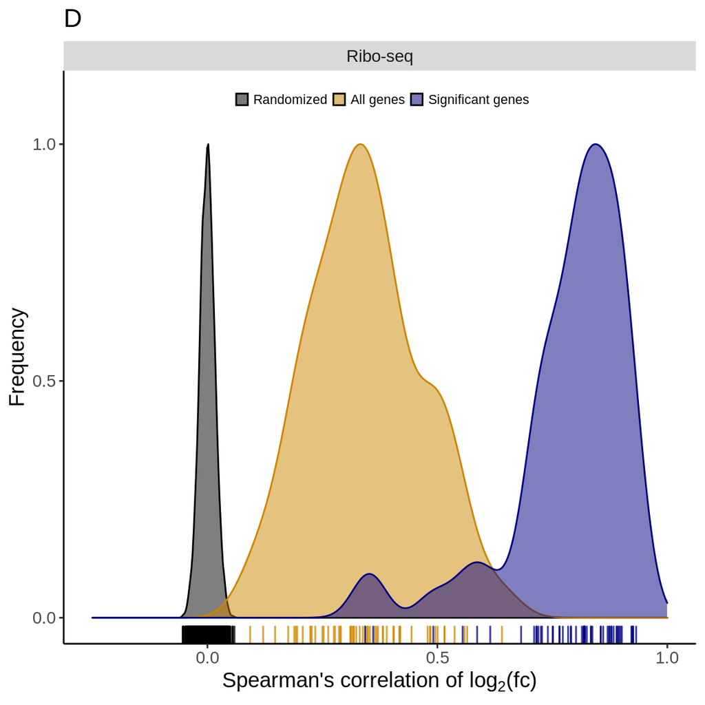

```r
all.cors.df <- bind_rows(cors.df2, randomized.cors, cors.df2.sig)

all.cors.df$seqtype <- factor(all.cors.df$seqtype, levels = c("ds_log2foldchange_rna", "ds_log2foldchange_ribo"))

all.cors.df$type <- factor(all.cors.df$type, levels = c("random", "actual", "actual_sig"))

d.fac.labs <- c("ds_log2foldchange_rna" = "RNA-seq",
                "ds_log2foldchange_ribo" = "Ribo-seq")

pd <- all.cors.df %>%
  filter(seqtype == "ds_log2foldchange_ribo") %>%
  ggplot(., aes(rs, fill = type, color = type))+
  geom_density(aes(y = ..scaled..), alpha = .5)+
  geom_rug(alpha = .5)+
  theme(panel.background = element_blank(),
        axis.line = element_line(color = "black"),
        text = element_text(size = 13),
        legend.position = c(.5, .95),
        legend.background = element_blank(),
        legend.text = element_text(size = 8),
        legend.key.size = unit(3 , "mm"),
        legend.direction = "horizontal",
        legend.spacing.x = unit(1, "mm"))+
  scale_x_continuous(limits = c(-.25, 1), breaks = c(0, .5, 1))+
  scale_y_continuous(breaks = c(0, .5, 1), limits = c(0, 1.1))+
  scale_color_manual(values = c("black", "orange3", "navy"), guide = FALSE)+
  scale_fill_manual(values = c("black", "orange3", "navy"), name = NULL, labels = c("Randomized", "All genes", "Significant genes"))+
  labs(x = expression(paste("Spearman's correlation of ", log[2], "(fc)", sep = "")),
       y = "Frequency",
       title = "D")+
  facet_wrap(~seqtype, labeller = as_labeller(d.fac.labs))

pd
```

### Panel E

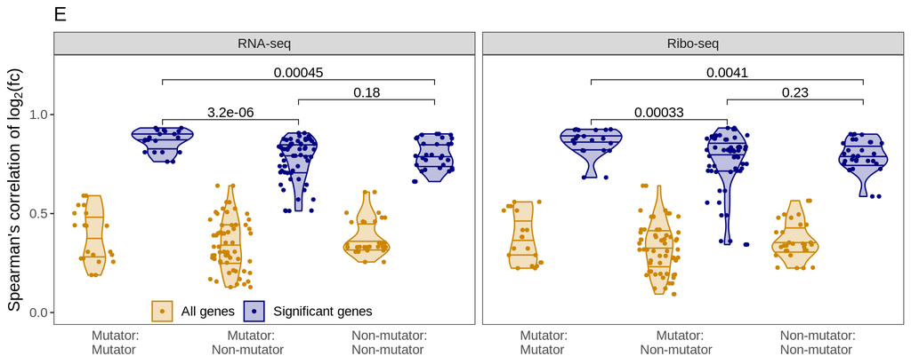

```r
muts <- all.data %>%
  filter(mutator == TRUE) %>%
  pull(line) %>%
  unique()

hash <- data.frame(mut_line = c(TRUE, TRUE, FALSE, FALSE),
                   mut_other_line = c(TRUE, FALSE, TRUE, FALSE),
                   class = c("mtm", "mtn", "mtn", "ntn"))

ddf <- all.cors.df %>%
  filter(type != "random") %>%
  mutate(mut_line = ifelse(line %in% muts, TRUE, FALSE),
         mut_other_line = ifelse(other_line %in% muts, TRUE, FALSE)) %>%
  left_join(., hash, by = c("mut_line", "mut_other_line")) %>%
  unite(comp.type, class, type, remove = FALSE)

my.comps <- list(c("mtm_actual_sig", "mtn_actual_sig"),
                 c("mtn_actual_sig", "ntn_actual_sig"),
                 c("mtm_actual_sig", "ntn_actual_sig"))

# sorry but this was the only way I could think of to space the labels correctly, it's not the same number
# of spaces in all of them either
xlabs <- c("           Mutator:\n          Mutator", "", "           Mutator:\n         Non-mutator", "", "            Non-mutator:\n           Non-mutator", "")

fac.labs <- c("ds_log2foldchange_rna" = "RNA-seq" , "ds_log2foldchange_ribo" = "Ribo-seq")

pe <- ddf %>%
  ggplot(., aes(comp.type, rs, fill = type, color = type))+
  geom_violin(draw_quantiles = c(.25, .5, .75), alpha = .25, position = "dodge")+
  geom_jitter(size = 1, height = 0, width = .3)+
  theme_bw()+
  theme(panel.background = element_blank(),
        text = element_text(size = 13),
        panel.grid = element_blank(),
        legend.position = c(.24, .05),
        legend.direction = "horizontal",
        legend.background = element_blank(),
        axis.ticks.x = element_blank())+
  labs(x = NULL,
       y = expression(paste("Spearman's correlation of ", log[2], "(fc)", sep = "")),
       title = "E")+
  facet_wrap(~seqtype, labeller = as_labeller(fac.labs))+
  scale_y_continuous(breaks = c(0, .5, 1), limits = c(0, 1.24))+
  stat_compare_means(comparisons = my.comps, method = "t.test")+
  scale_color_manual(values = c("orange3", "navy"), labels = c("All genes", "Significant genes"), name = NULL)+
  scale_fill_manual(values = c("orange3", "navy"), labels = c("All genes", "Significant genes"), name = NULL)+
  scale_x_discrete(labels = xlabs)

pe
```

### Panel F

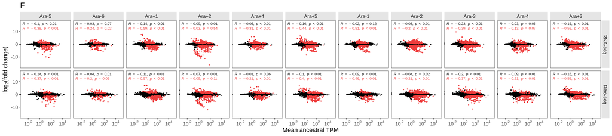

```r
# get the anc tpms and l2fcs for all and sig rna and riboseq genes separately
d.rna.sig <- all.data %>%
  filter(ds_padj_rna <= .01 & gene_type == "ECB") %>%
  select(line, target_id, anc_mean_tpm_rna, ds_log2foldchange_rna) %>%
  rename("l2fc" = "ds_log2foldchange_rna",
         "anc_tpm" = "anc_mean_tpm_rna")

d.ribo.sig <- all.data %>%
  filter(ds_padj_ribo <= .01 & gene_type == "ECB") %>%
  select(line, target_id, anc_mean_tpm_ribo, ds_log2foldchange_ribo) %>%
  rename("l2fc" = "ds_log2foldchange_ribo",
         "anc_tpm" = "anc_mean_tpm_ribo")

d.rna.all <- all.data %>%
  filter(gene_type == "ECB") %>%
  select(line, target_id, anc_mean_tpm_rna, ds_log2foldchange_rna) %>%
  rename("l2fc" = "ds_log2foldchange_rna",
         "anc_tpm" = "anc_mean_tpm_rna")

d.ribo.all <- all.data %>%
  filter(gene_type == "ECB") %>%
  select(line, target_id, anc_mean_tpm_ribo, ds_log2foldchange_ribo) %>%
  rename("l2fc" = "ds_log2foldchange_ribo",
         "anc_tpm" = "anc_mean_tpm_ribo")

# put them all together
fdf <- bind_rows("RNA-seq_all" = d.rna.all,
          "RNA-seq_sig" = d.rna.sig,
          "Ribo-seq_all" = d.ribo.all,
          "Ribo-seq_sig" = d.ribo.sig,
          .id = "d_type") %>%
  separate(d_type, into = c("seqtype", "dtype"), sep = "_")

# this allows us to not show non-significant points twice by allowing them to have an alpha of 0
# but they still contribute to the regressions, they're just not drawn in black and red
alpha.df <- fdf %>%
  group_by(seqtype, line, target_id) %>%
  tally() %>%
  ungroup()

fdf2 <- left_join(fdf, alpha.df) %>%
  mutate(alpha = ifelse(dtype == "all" & n ==2, "a", "b"))

fdf2$seqtype <- factor(fdf2$seqtype, levels = c("RNA-seq", "Ribo-seq"))

pf <- fdf2 %>%
  ggplot(., aes(anc_tpm, l2fc, color = dtype))+
  geom_point(size = .5, aes(alpha = alpha))+
  facet_grid(seqtype ~ line)+
  scale_x_log10(limits = c(1e-3, 1e5),
                labels = scales::trans_format("log10", scales::math_format(10^.x)),
                breaks = c(1e-2, 1, 1e2, 1e4))+
  scale_color_manual(values = c("black", "brown2"), guide = FALSE)+
  theme_bw()+
  theme(panel.background = element_blank(),
        text = element_text(size = 13),
        panel.grid = element_blank(),
        strip.background = element_rect(color = NA, fill = "grey90"))+
  labs(x = "Mean ancestral TPM",
       y = expression(paste(log[2], "(fold change)")),
       title = "F")+
  stat_cor(size = 2.7, label.y.npc = .98, p.accuracy = .01, r.accuracy = .01)+
  scale_y_continuous(limits = c(-17, 17))+
  scale_alpha_manual(values = c(0, 1), guide = FALSE)

pf
```

### Panel G

```r
n.bins = 10

#avg bin size, sd too
bin.size <- all.data %>%
  filter(ds_padj_rna<=.01 | ds_padj_rna<=.01) %>%
  select(anc_mean_tpm_rna, ds_log2foldchange_rna, line) %>%
  filter(!is.na(ds_log2foldchange_rna)) %>%
  mutate(equal_sized_bins = cut_number(anc_mean_tpm_rna, n.bins),
         updown = ifelse(ds_log2foldchange_rna > 0, "up", "down")) %>%
  group_by(equal_sized_bins, line) %>%
  tally() %>%
  ungroup() %>%
  pull(n)

paste("mean =", mean(bin.size), ", sd =", sd(bin.size))
```

```
## [1] "mean = 27.1454545454545 , sd = 13.5354352228595"
```

Make separate cuts for the RNAseq and riboseq datasets.

```r
rna.df <- all.data %>%
  filter(ds_padj_rna <= .01) %>%
  select(line, target_id, anc_mean_tpm_rna, ds_log2foldchange_rna) %>%
  mutate(even_cuts = cut_number(anc_mean_tpm_rna, n.bins),
         seqtype = "RNA-seq") %>%
  select(-anc_mean_tpm_rna) %>%
  dplyr::rename("l2fc" = "ds_log2foldchange_rna")

ribo.df <- all.data %>%
  filter(ds_padj_ribo <= .01) %>%
  select(line, target_id, anc_mean_tpm_ribo, ds_log2foldchange_ribo) %>%
  mutate(even_cuts = cut_number(anc_mean_tpm_ribo, n.bins),
         seqtype = "Ribo-seq") %>%
  select(-anc_mean_tpm_ribo)%>%
  dplyr::rename("l2fc" = "ds_log2foldchange_ribo")
```

The bins aren’t exactly equal on RNA-seq and riboseq but since there’s only 10 and they’re roughly equally size, the correspond to percentiles in increments of 10, sort of. I can just class them as .1-1

```r
rna.bins <- as.character(sort(unique(rna.df$even_cuts)))

ribo.bins <- as.character(sort(unique(ribo.df$even_cuts)))

rna.cut.trans.df <- data.frame(even_cuts = rna.bins,
                               cut_pos = 1:length(rna.bins))

ribo.cut.trans.df <- data.frame(even_cuts = ribo.bins,
                                cut_pos = 1:length(ribo.bins))
```

Join those

```r
rna.df2 <- left_join(rna.df, rna.cut.trans.df)

ribo.df2 <- left_join(ribo.df, ribo.cut.trans.df)
```

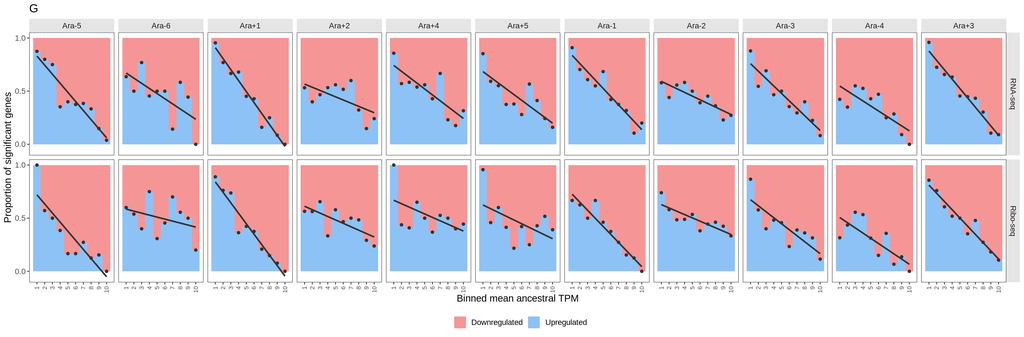

```r
gdf <- bind_rows(rna.df2, ribo.df2) %>%
  mutate(updown = ifelse(l2fc > 0, "up", "down")) %>%
  group_by(line, seqtype, cut_pos, updown) %>%
  tally() %>%
  pivot_wider(names_from = updown, values_from = n) %>%
  replace_na(list(up = 0, down = 0)) %>%
  mutate(pd = down / (up + down),
         pu = up / (up + down)) %>%
  pivot_longer(c(pd, pu)) %>%
  mutate(point = ifelse(name != "pd", value, NA))

gdf$seqtype <- factor(gdf$seqtype, levels = c("RNA-seq", "Ribo-seq"))

pg <- gdf %>%
  ggplot(., aes(cut_pos, value))+
  geom_col(width = 1, alpha = .5, aes(fill = name))+
  geom_smooth(aes(x = cut_pos, y = point), method = "lm", color = "grey20", se = FALSE)+
  geom_point(aes(cut_pos, point), color = "grey20")+
  facet_grid(seqtype~line)+
  scale_fill_manual(values = c("firebrick2", "dodgerblue2"),
                    name = NULL, labels = c("Downregulated", 'Upregulated'))+
  theme_bw()+
  theme(axis.text.x = element_text(angle = 90, vjust = .5, hjust = 1, size = 8),
        legend.position = "bottom",
        panel.background = element_blank(),
        text = element_text(size = 13),
        strip.background = element_rect(color = NA, fill = "grey90"),
        panel.grid = element_blank())+
  labs(x = "Binned mean ancestral TPM",
       y = "Proportion of significant genes",
       title = "G")+
  scale_x_continuous(breaks = 1:10)+
  scale_y_continuous(breaks = c(0, .5, 1))

pg
```

### Final figure

```r
top <- (pa | pb) + plot_layout(widths = c(.6, .4))

middle <- (pc | pd | pe) + plot_layout(widths = c(.4, .2, .4))

middle2 <- pf

bottom <- pg
```

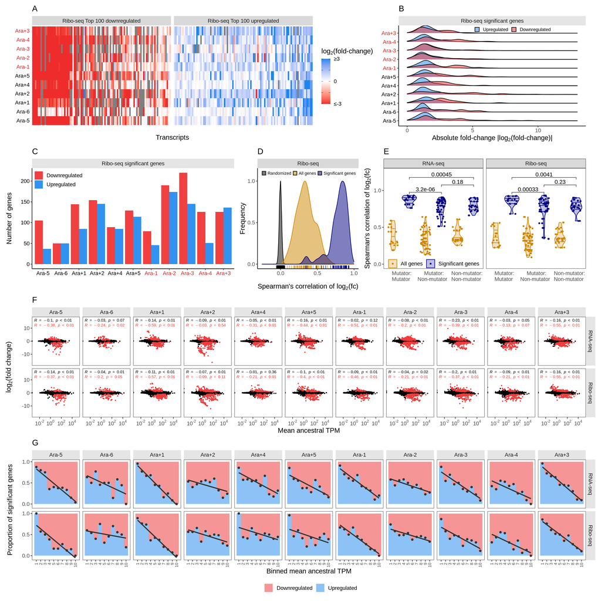

```r
(ff <- top / middle / middle2 / bottom)
```

```r
ggsave(ff, filename = "../../figures/c_fig_s6.pdf", width = 16, height = 16, device = cairo_pdf)

ggsave(ff, filename = "../../figures/c_fig_s6.png", width = 16, height = 16, dpi = 300)
```